# practicalmachinelearningwriteup

Roel M. Hogervorst

2016-05-15

# Introduction

This is a report describing how I applied machine learning techniques to predict the manner of barbell lifts for 6 people. This is part of the Coursera course practical machine learning.

This project is performed in R (version 3.2.4 Revised (2016-03-16 r70336) using Rstudio (0.99.893). Packages used: caret (6.0-68), dplyr (0.4.3), foreach ( 1.4.3), ggplot2 (2.1.0), readr (0.2.2) and dependent packages.

### description of experiment

*(from the [weight lift exercise dataset website](http://groupware.les.inf.puc-rio.br/har))*

Six young healthy participants were asked to perform one set of 10 repetitions of the Unilateral Dumbbell Biceps Curl in five different fashions: exactly according to the specification (Class A), throwing the elbows to the front (Class B), lifting the dumbbell only halfway (Class C), lowering the dumbbell only halfway (Class D) and throwing the hips to the front (Class E).

Class A corresponds to the specified execution of the exercise, while the other 4 classes correspond to common mistakes

The participants had accelerometers on the belt, forearm, arm, and dumbell.

### description of data

```r
suppressMessages(library(dplyr))
suppressMessages(library(ggplot2))
suppressMessages(library(caret))
trainingsetloc <- "https://d396qusza40orc.cloudfront.net/predmachlearn/pml-training.csv"
testsetloc <- "https://d396qusza40orc.cloudfront.net/predmachlearn/pml-testing.csv"
suppressMessages(library(randomForest))
suppressMessages(library(rpart))
suppressMessages(library(caTools))
library(foreach)
library(doParallel)
registerDoParallel(4) # this really helped a lot in speed.
```

```r
suppressWarnings(weightlift.train <- readr::read_csv(trainingsetloc))
names(weightlift.train)[1] <- "rownumber" # readr doesn't give col 1 a name.
dim(weightlift.train)
```

```
## [1] 19622   160
```

The trainingdataset contains 19622 rows and 160 variables. Per measurement location roll pitch and yaw, gyroscopic movement , accelaration and magnetic information in x,y,z directions was collected. For roll pitch and yaw of each of the four sensors the authors calculated eight features: mean, variance, standard deviation, max, min, amplitude, kurtosis and skew- ness, generating in total 96 derived feature sets. [^1]

# My approach

The dataset contains many measurments in a time frame that I don’t understand but at least many per second. One of my thoughts was to combine the measures close to eachother in time and perhaps calculate some features per movement. There is a cyclical pattern in some variables, f.i.:

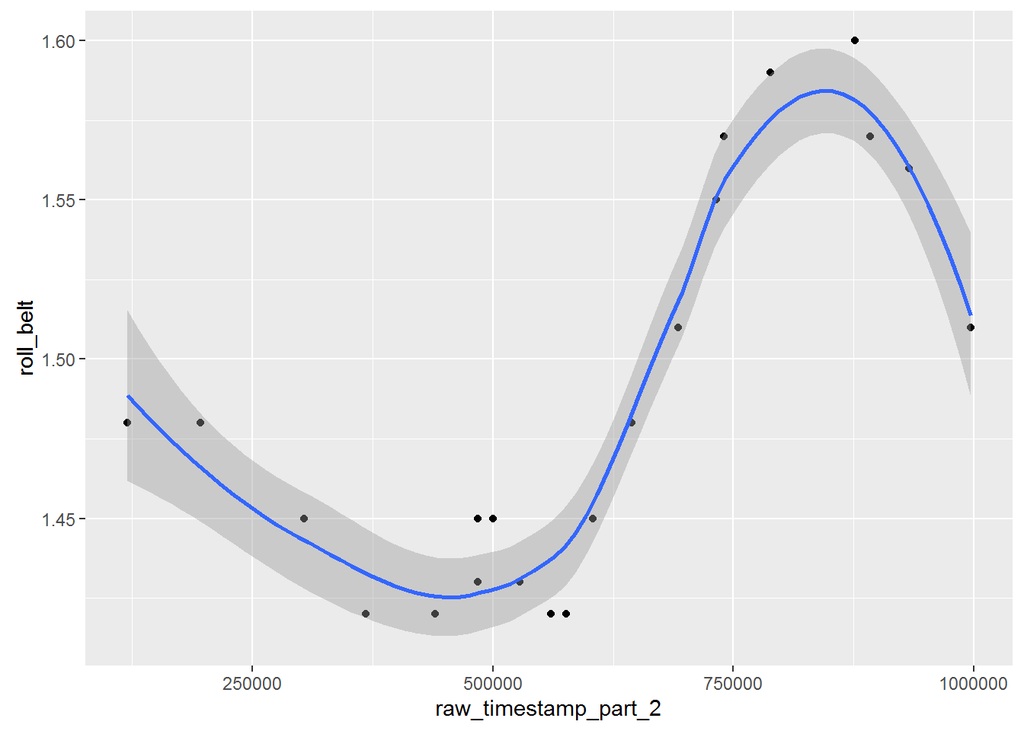

```r
weightlift.train %>% filter(user_name == "carlitos" & num_window == 12) %>%
    ggplot(aes(raw_timestamp_part_2, roll_belt)) +
    geom_point() + geom_smooth()
```

But when I combined multiple people or multiple windows, I couldn’t make this work. Ultimately I couldn’t find an intuitive way to combine windows, users and timestamps. I decided to start simple and find variables that combined well together. Since the avarage extracted features engineered by the original authors were only in part of rows and should be the same over identical windows I decided to exclude those created features while including the window numbers, time stamps and user names.

I created a normal dataset (excluding the created features) and a preprocessed dataset based on centering, scaling and Principal components analyses. Those datasets (`weightlift.train[,-not_trainingset]` and `pcatrainingset` respectively) were used with several models. I tried classification with rpart, random forests and logitboost. Rpart is a simple classification tree algorythm, random forest is an ensemble of multiple classification trees. Logitboost is an ensamble of logistic regressions.

I used cross validation 25 fold on every approach.

First a description of feature extraction.

## Feature extraction with PCA

I needed a vector of variables (columns) per bodypart but excluding the features that the original authors created.

```r
nogo <- c(1:7,  # identifiers
    grep("max_", names(weightlift.train)), # find names that have max_
    grep("min_", names(weightlift.train)),
    grep("var_", names(weightlift.train)),
    grep("stddev_", names(weightlift.train)),
    grep("avg_", names(weightlift.train)),
    grep("amplitude_", names(weightlift.train)),
    grep("skewness_", names(weightlift.train)),
    grep("kurtosis_", names(weightlift.train)),
    160 # classe it self.
)
# creation of variables.
belt <-  c(1:160)[-nogo][grep("belt",names(weightlift.train[,-nogo]) )]
arm<- c(1:160)[-nogo][grep("_arm",names(weightlift.train[,-nogo]) )]
dumbbel<-c(1:160)[-nogo][grep("dumbbell",names(weightlift.train[,-nogo]) )]
forearm<-c(1:160)[-nogo][grep("_forearm",names(weightlift.train[,-nogo]) )]
# could probably been done simpler
```

Then principal components analyses (PCA) per bodypart. I looked at the cumulative proportion of components. Since this information is very ugly I excluded the output below.

```r
# checking for principal components best solutions.
summary(princomp(weightlift.train[belt])) # 3 comp
summary(princomp(weightlift.train[,-nogo][,arm])) #2 comp
summary(princomp(na.omit(weightlift.train[,-nogo][,dumbbel]))) # missing values.
# 3 com is 91%. 4 = 97
summary(princomp(na.omit(weightlift.train[,forearm]))) #5 makes 96%
```

### Preprocessing the dataset into distinct dataset.

```r
#building preprocess functions to save space and to make things
#easier to read.
preprocessingfunction <- function(dataset, columnvector, n_components) {
    preobject <- preProcess(dataset[columnvector],
                            method= c("pca", "center", "scale"),
                            pcaComp = n_components,
                            na.remove = TRUE)
    preobject
} # need those objects later for testset. can't do a new pca on that set off course.
createpredataframe <- function(preobject, dataset, columnvector){
    df <- predict(preobject, dataset[columnvector])
    names(df) <- paste0(deparse(substitute(columnvector)),"_", names(df))
    df
}
# objects
belt_object <- preprocessingfunction(weightlift.train, belt, 3)
arm_object <- preprocessingfunction(weightlift.train, arm, 2)
dumbbel_object <- preprocessingfunction(weightlift.train, dumbbel, 3)
forearm_object <- preprocessingfunction(weightlift.train, forearm, 3)
# dframes
df_belt <- createpredataframe(belt_object,weightlift.train, belt )
df_arm <- createpredataframe(arm_object,weightlift.train, arm )
df_forearm <- createpredataframe(forearm_object,weightlift.train, forearm )
df_dumbbel <- createpredataframe(dumbbel_object,weightlift.train, dumbbel )
# combining dataset into one trainingset
pcatrainingset <-weightlift.train %>%
    select(2:7,160) %>%  # only select identifiers and classe
    cbind(df_belt, df_arm, df_forearm, df_dumbbel) # add pcacomponents
not_trainingset <- nogo[-c(2:7, 108)] # nogo but with identifiers and classe
```

## Building the models

I used the standard options in rpart but after a few trial and errors chose to set some maximum values for other algorytms. The random forest with standard options took so long that I killed the process after an hour. I later restricted the forests and used parallel processing. I started small and upped the maximum values to see if the accuracy would go up, I stopped when I reached ~ 98 % accuracy. Because I think the model would be overtrained. Perhaps I have already overtrained the models with that threshold, however the values are calculated with cross validation so the effect should be a bit more robust against overtraining.

```r
# crossvalidation set up
train_control<- trainControl(method="cv", number=25, savePredictions = TRUE)
# rpart with simple trainingset
set.seed(2356)
simple_model <- train(classe ~ .,
                      data = weightlift.train[,-not_trainingset],
                      method = "rpart",
                      trControl=train_control)
# rpart with preprocessed file.
set.seed(2356)
bodypca_model<- train(classe ~ ., data = pcatrainingset,
      method = "rpart", trControl=train_control)
# random forest on simple trainingset
set.seed(2346)
basic_rf <- train(classe ~ .,
                  data = weightlift.train[,-not_trainingset],
                  trControl=train_control,
                  method = "rf", maxnodes=80, ntree=5)
# random forest on preprocessed file
set.seed(2346)
bodypca_rf <- train(classe ~ ., data = pcatrainingset, trControl=train_control,
                    method = "rf", maxnodes=120, ntree=7)
# logitboost on simple trainingset
set.seed(2346)
basic_logitboost <- train(classe ~ ., data = weightlift.train[,-not_trainingset],
                          trControl=train_control,
                          method = "LogitBoost", nIter =4 )
# logitboost on preprocessed file
set.seed(2346)
bodypca_logitboost <- train(classe ~ .,
                          data = pcatrainingset,
                          trControl=train_control,
                          method = "LogitBoost", nIter =4 )
```

## Evaluating the models

```r
confusionMatrix(simple_model)
```

```
## Cross-Validated (25 fold) Confusion Matrix
##
## (entries are percentual average cell counts across resamples)
##
##           Reference
## Prediction    A    B    C    D    E
##          A 20.8  2.7  0.7  0.7  0.4
##          B  4.3  9.4  2.6  5.6  1.8
##          C  3.3  7.3 14.1 10.1  7.9
##          D  0.0  0.0  0.0  0.0  0.0
##          E  0.1  0.0  0.0  0.0  8.3
##
##  Accuracy (average) : 0.5256
```

```r
confusionMatrix(bodypca_model)
```

```
## Cross-Validated (25 fold) Confusion Matrix
##
## (entries are percentual average cell counts across resamples)
##
##           Reference
## Prediction    A    B    C    D    E
##          A 18.7  4.1  1.8  1.8  1.9
##          B  0.0  3.6  0.0  0.0  0.0
##          C  2.7  3.7 10.9  3.3  3.4
##          D  5.0  6.7  4.0 10.5  3.7
##          E  2.0  1.2  0.7  0.8  9.4
##
##  Accuracy (average) : 0.5312
```

```r
confusionMatrix(basic_rf)
```

```
## Cross-Validated (25 fold) Confusion Matrix
##
## (entries are percentual average cell counts across resamples)
##
##           Reference
## Prediction    A    B    C    D    E
##          A 28.2  0.1  0.0  0.0  0.0
##          B  0.0 19.0  0.1  0.0  0.0
##          C  0.0  0.3 17.2  0.4  0.0
##          D  0.1  0.0  0.1 15.8  0.3
##          E  0.0  0.0  0.0  0.1 18.1
##
##  Accuracy (average) : 0.9832
```

```r
confusionMatrix(bodypca_rf)
```

```
## Cross-Validated (25 fold) Confusion Matrix
##
## (entries are percentual average cell counts across resamples)
##
##           Reference
## Prediction    A    B    C    D    E
##          A 28.4  0.0  0.0  0.0  0.0
##          B  0.0 19.1  0.1  0.0  0.0
##          C  0.0  0.2 17.3  0.2  0.0
##          D  0.0  0.0  0.0 16.1  0.3
##          E  0.0  0.0  0.0  0.1 18.0
##
##  Accuracy (average) : 0.9903
```

```r
confusionMatrix(basic_logitboost)
```

```
## Cross-Validated (25 fold) Confusion Matrix
##
## (entries are percentual average cell counts across resamples)
##
##           Reference
## Prediction    A    B    C    D    E
##          A 29.7  0.5  0.0  0.0  0.0
##          B  0.0 16.9  0.4  0.0  0.0
##          C  0.0  0.5 16.5  0.4  0.0
##          D  0.0  0.1  0.2 15.5  0.3
##          E  0.0  0.0  0.0  0.1 18.7
##
##  Accuracy (average) : 0.9732
```

```r
confusionMatrix(bodypca_logitboost)
```

```
## Cross-Validated (25 fold) Confusion Matrix
##
## (entries are percentual average cell counts across resamples)
##
##           Reference
## Prediction    A    B    C    D    E
##          A 28.9  0.3  0.0  0.1  0.0
##          B  0.4 18.8  0.5  0.1  0.1
##          C  0.0  0.1 16.4  0.5  0.0
##          D  0.0  0.0  0.2 14.9  0.4
##          E  0.0  0.0  0.0  0.1 18.2
##
##  Accuracy (average) : 0.9718
```

My final choice for the model is a combination of logitboost and random forest on the testset and random forest on pca set.

My expected out of sample error would be around 90%. Theoretically the error would be $(0.97)\times(0.98)\times(0.98)$ But the predictors are not entirely independent. And there is already some combination at the logitboost and random forest models.

# Final prediction for testset

I will just use the models and decide by majority vote.

```r
suppressWarnings(weightlift.test <- readr::read_csv(testsetloc))
names(weightlift.test)[1] <- "rownumber"
# not we need to create a pca version of this set using the
# preProcess objects created and not a new pca.
# Since the names are identical this is not a problem.
tdf_belt <- createpredataframe(belt_object,weightlift.test, belt )
tdf_arm <- createpredataframe(arm_object,weightlift.test, arm )
tdf_forearm <- createpredataframe(forearm_object,weightlift.test, forearm )
tdf_dumbbel <- createpredataframe(dumbbel_object,weightlift.test, dumbbel )

pcatestset <-weightlift.test %>%
    select(2:7,160) %>%  # only select identifiers and classe
    cbind(tdf_belt, tdf_arm, tdf_forearm, tdf_dumbbel)
normaltestset <- weightlift.test[-not_trainingset]
```

Creating prediction for the three models. Since I do not want to give away spoilers I do not show the results of this assignment.

```r
normal_rf <- predict(basic_rf, normaltestset)
pca_rf <- predict(bodypca_rf, pcatestset)
pca_lb <-predict(bodypca_logitboost, pcatestset)
finalprediction <- data.frame( pca_rf, pca_lb, normal_rf)
Mode <- function(x) {
  ux <- unique(x)
  ux[which.max(tabulate(match(x, ux)))]
}
finalprediction$vote <- apply(finalprediction, 1, Mode)
finalprediction$vote
```

# Reference

[^1]: Velloso, E.; Bulling, A.; Gellersen, H.; Ugulino, W.; Fuks, H. Qualitative Activity Recognition of Weight Lifting Exercises. Proceedings of 4th International Conference in Cooperation with SIGCHI (Augmented Human ’13) . Stuttgart, Germany: ACM SIGCHI, 2013. Read more: http://groupware.les.inf.puc-rio.br/har#weight_lifting_exercises#ixzz48j1BZqba